# Mieten in Deutschland

Worin liegen Probleme und Schwierigkeiten im deutschen Mietmarkt

# Motivation

Die Mietpreise in Deutschland spielen eine wichtige Rolle für eine Vielzahl der deutschen Bevölkerung, doch nicht alle Gemeinden sind gleichermaßen von hohen Mieten betroffen. Faktoren wie die Lage einer Stadt, das Angebot an Wohnraum, das Alter der Gebäude oder der Familienstand der Bewohner beeinflussen die Höhe der Mieten. Dies werden Sie in diesem Projekt anhand von Zensus-Daten auf Gemeindeebene für das Jahr 2022 genau untersuchen. Besonders interessant ist dabei, wie sich Mietpreise nicht nur zwischen verschiedenen Städten, sondern auch innerhalb einer Stadt unterscheiden. Sie werden feststellen, dass die Ursachen für diese Mietunterschiede komplex und vielschichtig sind. Ihre Aufgabe ist es, durch fundierte Analysen herauszuarbeiten, welche Faktoren den größten Einfluss auf die Mietentwicklung haben. Auf Basis dieser Erkenntnisse könnten Sie Handlungsempfehlungen geben, die Politik und Stadtplaner nutzen können, um die Mietpreisentwicklung besser zu steuern und Wohnraum gerechter zu gestalten.

# Datengrundlage

In diesem Projekt werden Sie mit mehreren unterschiedlichen Datensätzen arbeiten. Zum Einen werden Sie Zensusdaten aus dem Jahr 2022 zur Demografie genauer betrachten. Zum Anderen werden Sie Daten zur Wohnungszählung in deutschen Gemeinden und Städten untersuchen. Schließlich benötigen Sie die dazugehörigen Kartendaten, um die Informationen später anschaulich visualisieren zu können. Dort werden Sie die Details der Karten einlesen und darüber hinaus Zahlen zu Mieten selbstständig herunterladen und importieren.

## Einlesen

Mittlerweile wohnen knapp 54% der Menschen in Deutschland zur Miete (Stand 2022). Somit ist Deutschland das Mieterland Nummer 1 in Europa. Im Vergleich dazu haben Länder wie Frankreich (36,6%), Italien (25,7%) oder Spanien (24%) einen deutlich geringeren Anteil an Mietern. Für die Politik ist es besonders interessant zu erfahren, wie sich nun die Mieten in den unterschiedlichen Gemeinden in Deutschland verteilen und ob es Regionen gibt, wo es besonders schwer wird eine neue Wohnung zu finden. Um dies zu beleuchten, sollen Sie nun die nachfolgenden Datensätze genauer analysieren.

1. Lesen Sie den Datensatz `Demografie_Zensus.csv` ein und speichern diesen als `demografie`. Der Datensatz `demografie` enthält für jede Gemeinde mehrere Beobachtungen. Dies liegt daran, dass für jede Altersgruppe der Personen eine eigene Beobachtung vorliegt. Allerdings ist der Datensatz im long-Format, d.h. nicht tidy und damit nicht so, wie Sie ihn für die weitere Datenanalyse benötigen. Nun soll der Datensatz so abgeändert werden, dass jede Gemeinde nur noch eine Beobachtung darstellt. Passen Sie den Datensatz so an, dass Sie für jede `Altersgruppe` eine eigene Spalte erstellen und dort jeweils die Anzahl der Menschen, die Sie der Spalte `Anzahl pro Altersgruppe` entnehmen können, eingetragen wird.

Darüberhinaus sollen Sie nun einen weiteren Datensatz `Wohnungen_Zensus.csv` einlesen, welcher Informationen zu den einzelnen Wohnungen in den Gemeinden enthält. Speichern Sie den Datensatz in der Variable `wohnungen` ab. Vereinen Sie ihren Datensatz `demografie` mit dem Datensatz `wohnungen` und speichern Sie diesen als `zensus_daten` ab. Verwenden Sie für ihren “Join” die Variable `Regionalschlüssel`.

Beantworten Sie anschließend die Frage, welche Art von “Join” sich in diesem Fall anbietet und warum?

Ein Left-Join eignet sich hier am besten, da alle passenden Informationen aus “wohnungen” zu “demofrafie” hinzugefügt werden. Ein full-Join würde alle Zeilen aus beiden Datensätzen nehmen. Er würde auch Gemeinden aus “wohnungen” einbeziehen, welche nicht in “demografie” vorkommen, was hier nicht nötig ist. Ein inner-Join fügt nur Daten zusammen, die in beiden Datensätzen vorkommen, was zu Datenverlusten führen kann.

2. Schränken Sie nun Ihren erstellten Datensatz auf folgende Variablen ein:
- `Name_Gemeinde`
- `Landkreis`
- `0_Insgesamt_`
- `Regionalschlüssel`
- `Alter_infr__` (01 bis 11)
- `FAMSTND_KURZ__` (1 bis 5)
- `Einwanderungserf_ausf__1`
- `Einwanderungserf_ausf__21`
- `Einwanderungserf_ausf__22`
- `Einwanderungserf_ausf__3`
- `Staatsange_kurz__1`
- `Staatsange_kurz__2`
- `BAUJAHR_10JA__` (01 bis 10)
- `WOHNFLAECHE_20S__` (01 bis 10)
- `QMMIETE`
- `LEQ`
- `ETQ`
- `FLAECHE`
- `Wohnungen_gesamt`

Beschreiben Sie weiterhin den Datensatz. Orientieren Sie sich hierbei an folgenden Fragen und nutzen Sie das bereitgestellte README zum Datensatz:

- Was ist eine Beobachtung?
- Wie viele Variablen hat der Datensatz?
- Welche Variablen enthält der Datensatz? Bitte beschreiben Sie diese Variablen kurz!
- Welche Städte mit mehr als 500.000 Einwohnern sind im Datensatz?
- In wie viel Prozent der Fälle haben Sie Informationen zu allen Variablen einer Beobachtung?

Eine Beobachtung in diesem Datensatz bezieht sich in der Regel auf eine Gemeinde, die durch bestimmte gesellschaftliche und demografische Merkmale sowie Wohnungsdaten beschrieben wird. Der Datensatz besitzt die folgenden 51 Variablen:

- Regionalschlüssel: Amtlicher Gemeindeschlüssel (AGS)  
  – Name_Gemeinde: Name der regionalen Einheit  
  – Landkreis: Name des Landkreises  
  – BAUJAHR_10JA__01: Wohnungen in Gebäude mit Wohnraum mit Baujahr vor 1919 (Anzahl)  
  – BAUJAHR_10JA__02: Wohnungen in Gebäude mit Wohnraum mit Baujahr von 1919 bis 1949 (Anzahl)  
  – BAUJAHR_10JA__03: Wohnungen in Gebäude mit Wohnraum mit Baujahr von 1950 bis 1959 (Anzahl)  
  – BAUJAHR_10JA__04: Wohnungen in Gebäude mit Wohnraum mit Baujahr von 1960 bis 1969 (Anzahl)  
  – BAUJAHR_10JA__05: Wohnungen in Gebäude mit Wohnraum mit Baujahr von 1970 bis 1979 (Anzahl)  
  – BAUJAHR_10JA__06: Wohnungen in Gebäude mit Wohnraum mit Baujahr von 1980 bis 1989 (Anzahl)  
  – BAUJAHR_10JA__07: Wohnungen in Gebäude mit Wohnraum mit Baujahr von 1990 bis 1999 (Anzahl)  
  – BAUJAHR_10JA__08: Wohnungen in Gebäude mit Wohnraum mit Baujahr von 2000 bis 2009 (Anzahl)  
  – BAUJAHR_10JA__09: Wohnungen in Gebäude mit Wohnraum mit Baujahr von 2010 bis 2015 (Anzahl)  
  – BAUJAHR_10JA__10: Wohnungen in Gebäude mit Wohnraum mit Baujahr 2016 und später (Anzahl)  
  – WOHNFLAECHE_20S_01: Wohnungen in Gebäuden mit Wohnraum mit einer Fläche von unter 40m² (Anzahl)  
  – WOHNFLAECHE_20S_02: Wohnungen in Gebäuden mit Wohnraum mit einer Fläche von 40m² bis 59m² (Anzahl)  
  – WOHNFLAECHE_20S_03: Wohnungen in Gebäuden mit Wohnraum mit einer Fläche von 60m² bis 79m² (Anzahl)  
  – WOHNFLAECHE_20S_04: Wohnungen in Gebäuden mit Wohnraum mit einer Fläche von 80m² bis 99m² (Anzahl)  
  – WOHNFLAECHE_20S_05: Wohnungen in Gebäuden mit Wohnraum mit einer Fläche von 100m² bis 119m² (Anzahl)  
  – WOHNFLAECHE_20S_06: Wohnungen in Gebäuden mit Wohnraum mit einer Fläche von 120m² bis 139m² (Anzahl)  
  – WOHNFLAECHE_20S_07: Wohnungen in Gebäuden mit Wohnraum mit einer Fläche von 140m² bis 159m² (Anzahl)  
  – WOHNFLAECHE_20S_08: Wohnungen in Gebäuden mit Wohnraum mit einer Fläche von 160m² bis 179m² (Anzahl)  
  – WOHNFLAECHE_20S_09: Wohnungen in Gebäuden mit Wohnraum mit einer Fläche von 180m² bis 199m² (Anzahl)  
  – WOHNFLAECHE_20S_10: Wohnungen in Gebäuden mit Wohnraum mit einer Fläche von 200m² und mehr (Anzahl)  
  – QMMIETE: Durchschnittliche Nettokaltmiete pro Quadratmeter (in €/m²): Die durchschnittliche Nettokaltmiete/qm ist das Verhältnis zwischen der Summe der Quadratmetermiete der Wohnungen und der Summe der Wohnungen. Die Berechnung erfolgt für vermietete Wohnungen in Wohngebäuden (ohne Wohnheime). Mietfrei überlassene Wohnungen werden aus der Berechnung ausgeschlossen.  
  – LEQ: Leerstandsquote (in %): Die Leerstandsquote (Wohnungen) stellt den Anteil der leerstehenden Wohnungen an allen bewohnten und leerstehenden Wohnungen dar. Nicht berücksichtigt sind: Ferien- und Freizeitwohnungen sowie gewerblich genutzte Wohnungen. Die Berechnung erfolgt für Wohnungen in Wohngebäuden (ohne Wohnheime).  
  – ETQ: Eigentümerquote (in %): Die Eigentümerquote stellt den Anteil der von Eigentümerinnen/ Eigentümern bewohnten Wohnungen an allen bewohnten Wohnungen dar. Nicht berücksichtigt sind: Leer stehende Wohnungen, Ferien- und Freizeitwohnungen sowie gewerblich genutzte Wohnungen. Die Berechnung erfolgt für Wohnungen in Wohngebäuden (ohne Wohnheime).  
  – FLAECHE: Durchschnittliche Fläche je Wohnung: Die durchschnittliche Wohnungsgröße in m² ist das Verhältnis zwischen der Gesamtfläche in m² und der Gesamtzahl der Wohnungen. Nicht berücksichtigt sind gewerblich genutzte Wohnungen. Die Berechnung erfolgt für Wohnungen in Wohngebäuden (ohne Wohnheime).  
  – 0_Insgesamt_: Bevölkerung insgesamt (Anzahl)  
  – Staatsange_kurz__1: Personen mit deutscher Staatsangehörigkeit (Anzahl)  
  – Staatsange_kurz__2: Personen mit ausländischer Staatsangehörigkeit (einschl. Personen mit einer Staatsangehörigkeit „Staatenlos“, „Ungeklärt“ und „Ohne Angabe“) (Anzahl)  
  – Alter_infr__01: Personen in der Altersklasse “Unter 3 Jahren” (Anzahl)  
  – Alter_infr__02: Personen in der Altersklasse “3 - 5 Jahre” (Anzahl)  
  – Alter_infr__03: Personen in der Altersklasse “6 - 9 Jahre” (Anzahl)  
  – Alter_infr__04: Personen in der Altersklasse “10 - 15 Jahre” (Anzahl)  
  – Alter_infr__05: Personen in der Altersklasse “16 - 18 Jahre” (Anzahl)  
  – Alter_infr__06: Personen in der Altersklasse “19 - 24 Jahre” (Anzahl)  
  – Alter_infr__07: Personen in der Altersklasse “25 - 39 Jahre” (Anzahl)  
  – Alter_infr__08: Personen in der Altersklasse “40 - 59 Jahre” (Anzahl)  
  – Alter_infr__09: Personen in der Altersklasse “60 - 66 Jahre” (Anzahl)  
  – Alter_infr__10: Personen in der Altersklasse “67 - 74 Jahre” (Anzahl)  
  – Alter_infr__11: Personen in der Altersklasse “75 Jahre und älter” (Anzahl)  
  – FAMSTND_KURZ__1: Personen mit dem Familienstand “Ledig” (Anzahl)  
  – FAMSTND_KURZ__2: Personen mit dem Familienstand “Verheiratet / eingetragene Lebenspartnerschaft” (Anzahl)  
  – FAMSTND_KURZ__3: Personen mit dem Familienstand “Verwitwet / eingetragene(r) Lebenspartner(in) verstorben” (Anzahl) – FAMSTND_KURZ__4: Personen mit dem Familienstand “Geschieden / eingetragene Lebenspartnerschaft aufgehoben” (Anzahl – FAMSTND_KURZ__5: Personen mit dem Familienstand “Ohne Angabe” (Anzahl)  
  – Einwanderungserf_ausf__1: Personen ohne Einwanderungsgeschichte (Anzahl)  
  – Einwanderungserf_ausf__21: Eingewanderte (Anzahl)  
  – Einwanderungserf_ausf__22: Nachkommen von Eingewanderten (Anzahl)  
  – Einwanderungserf_ausf__3: Personen mit einseitiger Einwanderungsgeschichte (Anzahl)  
  – Wohnungen_gesamt: Gesamtanzahl der Wohnungen in den einzelnen Gemeinden

Die Städte mit mehr als 50000 Einwohnern sind Hamburg, Hannover, Bremen, Düsseldorf, Duisburg, Essen, Köln, Dortmund, Frankfurt am Main, Stuttgart, München, Nürnberg, Berlin, Dresden, Leipzig.In 0% der Faelle haben wir Informationen zu allen Variablen einer Beobachtung.

3. Erstellen Sie in einem nächsten Schritt weitere Variablen, die Sie in ihrer Analyse benötigen. Diese Variablen sollen folgende Eigenschaften umfassen:
- Je eine Variable für den Anteil kleiner, mittlerer und großer Wohnungen, wobei kleine Wohnungen (<= 59 m²), mittlere Wohnungen (60 - 159 m²) und große Wohnungen (>= 160 m²) als Anteil an den `Wohnungen_gesamt` abgebildet werden sollen.
- Je eine Variable für den Anteil neuer und alter Wohnungen. Neue Wohnungen umfassen alle Wohnungen, die ab 2010 gebaut wurden und alte Wohnungen sind alle Wohnungen vor 1950. Auch hier soll wieder der Anteil an allen Wohnungen (`Wohnungen_gesamt`) berechnet werden.
- Das Verhältnis von Personen mit deutscher Staatsangehörigkeit zu allen Bürgern der Gemeinde einschliesslich Personen mit ausländischer Staatsangehörigkeit und Personen mit dem Status “staatenlos”, “ungeklärt” und “ohne Angabe” über `Staatsange_kurz__1` und `Staatsange_kurz__2`. Hier soll der Anteil deutscher Bürger im Verhältnis zu allen Bürgern der Gemeinde bestimmt werden.

*Hinweis:* Runden Sie die Werte für die neu erstellte Variable sinnvoll!

4. Um Karten wie bspw. in der Case Study zu erstellen, benötigen Sie Kartendaten in Form von Shapefiles (Endung .shp). In einer späteren Analyse sollen Sie die einzelnen Städte, bzw. deren Bezirke visualisieren. Hierzu müssen Sie zuerst die nötigen Shape-Files einlesen und Details zu den einzelnen Bezirken herunterladen. Sie sollen Analysen auf Basis von 1km Gitterdaten durchführen. Deshalb sollten Sie sich [diese Geogitter-Daten für die Nettokaltmieten vom statistischen Bundesamt herunterladen](https://www.zensus2022.de/static/Zensus_Veroeffentlichung/Zensus2022_Durchschn_Nettokaltmiete.zip). Speichern Sie die zip-Datei im Ordner `Daten` ab. Weiterhin sollen Sie [die Geogitter-Daten für die Leerstandsquoten herunterladen](https://www.zensus2022.de/static/Zensus_Veroeffentlichung/Marktaktive_Leerstandsquote_in_Gitterzellen.zip). Speichern Sie auch diese im Ordner `Daten` ab und lesen Sie anschließend die .csv-Dateien für Nettokaltmiete und Leerstandsquote (für das 1km-Gitter) ein. Weiterhin benötigen Sie die Karteninformationen für die Visualisierung der Daten. Diese befinden sich in der Datei `Shapefile_Zensus.shp`. Lesen Sie diese mit Hilfe von `st_read()` ein und speichern Sie als `shape_file` ab. Benennen Sie die Variablen in `shape_file` folgendermaßen um:
- gemndnm = Name_Gemeinde
- x_mp_1k = x_mp_1km
- y_mp_1k = y_mp_1km
- gttr1km = gitter1km

Joinen Sie nun noch die beiden Dataframes zu Miete und Leerstandsquote zu `shape_file` hinzu. Verwenden Sie `y_mp_1km` und `x_mp_1km` als Joinvariable.

*Hinweis:* Im ersten Teil der Case-Study wird eine ZIP-Datei in R entpackt. Gehen Sie hier gleich vor!

# Konsistenzcheck

Nun haben Sie alle Daten zusammen, die Sie für die Analyse der Mieten in Deutschland für das Jahr 2022 benötigen. Somit können Sie nun beginnen, die ersten Analysen zu tätigen!

5. Im Datensatz `zensus_daten`, welchen Sie zuvor eingelesen, aufgearbeitet und zusammengefügt haben, befinden sich einige große deutsche Städte. Sie möchten nun gerne die Daten, welche Sie dort aufbereitet haben, verifizieren. Dafür sollten Sie sich eine externe Quelle suchen, auf deren Basis Sie die Gesamtbevölkerung der unten aufgeführten großen Städte in Deutschland mit denen aus dem Datensatz vergleichen. Die Bevölkerungszahlen in ihrem Datensatz stammen aus dem Jahr 2022.

Erstellen Sie eine Tabelle mit allen nachfolgenden Städten aus dem Datensatz und deren Einwohnern. Achten Sie auf eine schöne Darstellung ihrer Tabelle mittels der Pakete `kableExtra` oder `gt`.

Im Detail sollen folgende Städte in der Tabelle genauer betrachtet werden:

- “Berlin, Stadt”, “Hamburg, Freie und Hansestadt”, “München, Landeshauptstadt”, “Köln, Stadt”, “Frankfurt am Main, Stadt”, “Stuttgart, Landeshauptstadt”, “Düsseldorf, Stadt”, “Leipzig, Stadt”, “Augsburg”, “Ingolstadt”, “Ulm, Universitätsstadt”, “Reutlingen, Stadt”

Sind die Anzahl der Einwohner in ihren Daten korrekt? Nutzen Sie eine externe Datenquelle (bitte benennen und in ihrer Antwort verlinken) und führen Sie einen kurzen Konsistenzcheck durch.

| Stadt | Bevölkerung 2022 | Bevölkerung 2022 Extern | Differenz |
| --- | --- | --- | --- |
| Berlin, Stadt | 3596999 | 3596999 | 0 |
| Hamburg, Freie und Hansestadt | 1808846 | 1808846 | 0 |
| München, Landeshauptstadt | 1478638 | 1478638 | 0 |
| Köln, Stadt | 1017355 | 1017355 | 0 |
| Frankfurt am Main, Stadt | 743268 | 743268 | 0 |
| Stuttgart, Landeshauptstadt | 610458 | 610458 | 0 |
| Düsseldorf, Stadt | 611258 | 611258 | 0 |
| Leipzig, Stadt | 598899 | 598899 | 0 |
| Augsburg | 294647 | 294647 | 0 |
| Ingolstadt | 136468 | 136468 | 0 |
| Ulm, Universitätsstadt | 127116 | 127116 | 0 |
| Reutlingen, Stadt | 116925 | 116925 | 0 |

Als externe Datenquelle wurden die Bevoelkerungszahlen aus dem Zensus 2022 verwendet (https://www.zensus2022.de/static/Zensus_Veroeffentlichung/Regionaltabelle_Bevoelkerung.xlsx). Beim Vergleich der externen Daten mit den internen Daten wurden keine Differenzen festgestellt und somit ist der Konsistenzcheck erfolgleich gewesen. Daraus folgt, dass wir annehmen können, dass unsere Daten keine widersprüchlichen oder fehlerhaften Informationen enthalten.

# Deskriptive Analysen

6. Schauen Sie sich in einem nächsten Schritt an, wie die Variablen im Datensatz `zensus_daten` über alle Gemeinden und Städte hinweg verteilt sind. Konkret sollten Sie eine Tabelle erstellen, welche Informationen zu folgenden Variablen enthält:
- verschiedene Baujahre der Wohnungen
- durchschnittlicher Quadratmeterpreis
- Leerstandsquote
- Eigentümerquote
- durchschnittliche Wohnfläche
- Anteil kleiner, mittlerer und großer Wohnungen
- Einwohner

Berechnen Sie zu jeder Variablen den Mittelwert, den Median, das Minimum, das Maximum, die Standardabweichung, sowie das 25%- und das 75%- Quantil bezogen auf alle Gemeinden. Bei den Variablen Leerstandsquote, Eigentümerquote, durchschnittliche Wohnfläche, durchschnittlicher Quadratmeterpreis und Anteil kleiner, mittlerer und großer Wohnungen soll der Mittelwert als gewichteter Mittelwert nach der absoluten Anzahl an Wohnungen berechnet werden. Heben Sie die Variablen in ihrer Tabelle entsprechend hervor, bei denen sie den gewichteten Mittelwert bestimmt haben.

Beschreiben und interpretieren Sie Ihre Tabelle. Begründen Sie auch, warum es bei den genannten Variablen sinnvoll ist, den nach Anzahl der Wohnungen gewichteten Mittelwert zu verwenden. Würde es ihrer Ansicht nach Sinn machen, statt nach Wohnungen nach Einwohnern zu gewichten? Begründen Sie auch, bei welchen Variablen eine Betrachtung der Mittelwerte, Standardabweichungen und Quantile ihrer Ansicht nach als sinnvoll erscheint. Wo ist dies weniger gut geeignet? Bei welchen Variablen gibt es Auffälligkeiten? Gibt es Ausreißer nach oben oder unten?

Achten Sie auf eine schöne Darstellung ihrer Tabelle mittels der Pakete `kableExtra` oder `gt`!

*Hinweis 1:* Wenn bei den Variablen Wohnungen_klein, Wohnungen_mittel und Wohnungen_groß Werte mit `NaN` oder `Inf` auftauchen, so ersetzen Sie diese durch `NAs`.

*Hinweis 2:* Die Anzahl der Wohnungen nach Alters- bzw. Baujahrsgruppen können den Variablen entnommen werden, welche mit `BAUJAHR_10JA__` beginnen.

Deskriptive Statistiken inklusive Baujahrsgruppen

|  | Mittelwert | Standardabweichung | Minimum | Q1 | Median | Q3 | Maximum |
| --- | --- | --- | --- | --- | --- | --- | --- |
| Baujahr vor 1919 | 527.59 | 5692.23 | 0.00 | 50.00 | 111.00 | 316.00 | 520700.00 |
| Baujahr von 1919 bis 1949 | 410.88 | 3526.83 | 0.00 | 28.00 | 69.00 | 221.00 | 281150.00 |
| Baujahr von 1950 bis 1959 | 458.39 | 3943.09 | 0.00 | 20.00 | 60.00 | 198.00 | 193475.00 |
| Baujahr von 1960 bis 1969 | 608.00 | 4351.00 | 0.00 | 30.00 | 94.00 | 338.00 | 261728.00 |
| Baujahr von 1970 bis 1979 | 579.82 | 3426.81 | 0.00 | 33.00 | 113.00 | 389.00 | 239857.00 |
| Baujahr von 1980 bis 1989 | 395.81 | 2675.96 | 0.00 | 29.00 | 91.00 | 295.00 | 223683.00 |
| Baujahr von 1990 bis 1999 | 479.42 | 2131.64 | 0.00 | 39.00 | 124.00 | 407.00 | 141456.00 |
| Baujahr von 2000 bis 2009 | 251.93 | 1114.19 | 0.00 | 23.00 | 69.00 | 204.00 | 57008.00 |
| Baujahr von 2010 bis 2015 | 129.78 | 828.15 | 0.00 | 8.00 | 26.00 | 88.00 | 45389.00 |
| Baujahr 2016 und später | 155.93 | 1101.45 | 0.00 | 9.00 | 33.00 | 115.00 | 80878.00 |
| Quadratmeterpreis | 7.00 | 1.38 | 0.00 | 4.82 | 5.53 | 6.46 | 13.84 |
| Leerstandsquote | 4.34 | 3.11 | 0.00 | 3.45 | 4.74 | 6.58 | 50.00 |
| Eigentümerquote | 44.36 | 12.72 | 13.49 | 60.22 | 68.77 | 76.11 | 100.00 |
| Wohnfläche | 94.32 | 15.41 | 64.92 | 104.98 | 116.20 | 125.11 | 239.54 |
| KleineWohnungen | 0.23 | NA | 0.23 | 0.23 | 0.23 | 0.23 | 0.23 |
| MittlereWohnungen | 0.68 | NA | 0.68 | 0.68 | 0.68 | 0.68 | 0.68 |
| GroßeWohnungen | 0.09 | NA | 0.09 | 0.09 | 0.09 | 0.09 | 0.09 |
| Einwohner | 7668.39 | 49517.10 | 9.00 | 655.00 | 1797.00 | 5506.00 | 3596999.00 |

Die Tabelle gibt einen Überblick über verschiedenen Aspekte der Wohnungsbautätigkeit in Gemeinden, wie zum Beispiel die Anzahl gebauter Wohnungen in einem bestimmten Zeitraum, die Miete pro Quadratmeter, die Leerstandsquote, die Eigentümerquote, die Wohnfläche pro Wohnung sowie die Verteilung der Wohnungstypen (kleine, mittlere, große Wohnungen) und die Einwohnerzahlen. Diese Werte werden anhand von Kennzahlen wie Mittelwert, Median, Minimum, Maximum, Standardabweichung und den Quartilen analysiert.

Die Verwendung des gewichteten Mittelwerts ist sinnvoll, da er die verschiedenen Größen der Gemeinden berücksichtigt. Eine Gewichtung nach Einwohnerzahl wäre weniger geeignet, da sie die Verteilung der Wohnungen verzerrt und dadurch würden die Ergebnisse in größeren Städten wie Berlin stark beeinflusst werden. Die Analyse von Mittelwerten, Standardabweichungen und Quartilen ist nützlich, um die Verteilung und Streuung von Variablen wie den Quadratmeterpreisen und der Eigentümerquote zu verstehen.

Außerdem ist auffällig, dass bei der Einwohnerverteilung der Mittelwert durch große Städte wie Berlin verzerrt wird, was den Unterschied zum Median erklärt.

7. Die Verteilung des Alters der Wohnungen scheint bereits ein Faktor zu sein, der sich auf den Mietpreis auswirken kann, da doch deutlich weniger Wohnungen ab den 2000er Jahren gebaut wurden. Nun sollen Sie etwas tiefer in ihren Datensatz eintauchen und weitere Faktoren analysieren, die sich zum einen zwischen Städten und Gemeinden unterscheiden und darüberhinaus herausfinden, ob diese Faktoren einen Einfluss auf den Mietpreis haben:

Erstellen Sie 4 Punktdiagramme in denen Sie

- die durchschnittliche Fläche je Wohnung,
- die Leerstandsquote je Gemeinde,
- Anteil alter Wohnungen je Gemeinde,
- Anteil neuer Wohnungen je Gemeinde,

auf der x-Achse abtragen und auf der y-Achse jeweils die durchschnittliche Nettokaltmiete pro Quadratmeter. Verwenden Sie hier nun alle Gemeinden im Datensatz, um ein Gesamtbild zu erhalten und ordnen Sie die 4 Diagramme so an, dass ein Vergleich zwischen den Schaubildern schnell und einfach möglich ist. Beschreiben und interpretieren Sie die Diagramme. Gehen Sie hierbei insbesondere auf folgende Fragen ein:

- Welche Variablen scheinen besonders stark mit dem Mietpreis korreliert zu sein?
- Was könnte die Zusammenhänge erklären?

*Hinweis:* Achten Sie darauf das bei nebeneinander angeordneten Grafiken die y-Achse gleich sein sollte.

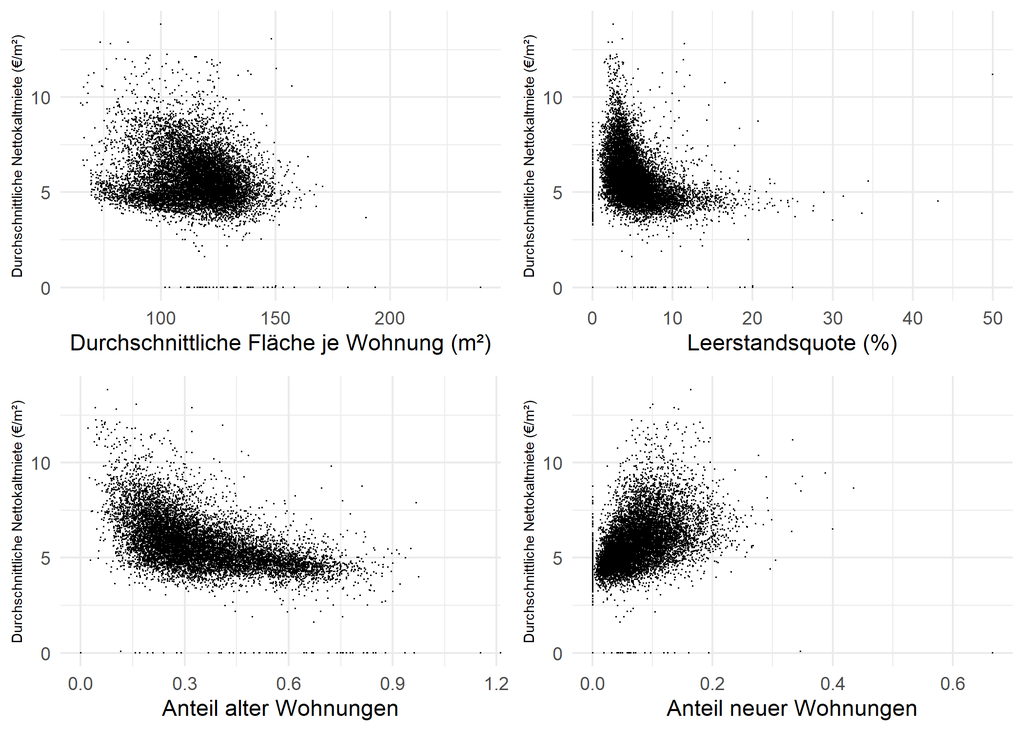

Die vier Punktdiagramme zeigen jeweils die Beziehung zwischen den Variablen Durchschnittliche Wohnfläche, Leerstandsquote, Anteil alter Wohnungen, Anteil neuer Wohnungen(x-Achse) und der durchschnittlichen Nettokaltmiete pro Quadratmeter (y-Achse) für verschiedenen Gemeinden (jeder Punkt bildet eine Gemeinde ab).

Hat die durchschnittliche Fläche einer Wohnung einen Einfluss auf die durchschnittliche Nettokaltmiete?

In dem Punktediagramm, das den Zusammenhang zwischen der durchschnittlichen Nettokaltmiete und der durchschnittlichen Fläche je Wohnung zeigt, fällt auf, dass die Punkte relativ dicht beieinander liegen. Das bedeutet, dass die Werte eine hohe Dichte aufweisen, sich also in einem bestimmten Bereich konzentrieren. Besonders auffällig sind die Ausreißer nach oben, die vor allem bei den Wohnungen mit kleineren Flächen zu beobachten sind. Dies lässt sich damit erklären, dass es in einigen Gemeinden eine sehr hohe Nachfrage nach Wohnraum gibt, wodurch die Mietpreise höher sind.

Hat die Leerstandsquote einen Einfluss auf die durchschnittliche Nettokaltmiete?

Die Leerstandsquote scheint einen Einfluss auf die durchschnittliche Nettokaltmiete zu haben. Aus dem Diagramm geht hervor, dass die Mieten tendenziell mit zunehmender Leerstandsquote sinken. Zwar lässt sich kein ganz eindeutiger Trend feststellen, doch ist eine Korrelation erkennbar. In ländlichen Gemeinden oder in Gebieten mit wenigen attraktiven Wohnangeboten könnte eine hohe Leerstandsquote tatsächlich die Folge einer geringeren Nachfrage nach Wohnungen sein. Diese geringere Nachfrage führt wiederum zu niedrigeren Mietpreisen.

Hat der Anteil an alten Wohnungen einen Einfluss auf die durchschnittliche Nettokaltmiete?

Auch beim Anteil an alten Wohnungen lässt sich ein Zusammenhang zur durchschnittlichen Nettokaltmiete erkennen. Mit einem höheren Anteil an alten Wohnungen sinken tendenziell die Mietpreise. Dies ist wahrscheinlich darauf zurückzuführen, dass alte Wohnungen oft weniger attraktiv sind als neuere, etwa wegen ihrer Ausstattung, Energieeffizienz oder des Zustands. In Gegenden mit vielen alten Wohnungen werden die Mietpreise deshalb oft niedriger angesetzt. Es gibt jedoch auch Gemeinden, in denen der Anteil an alten Wohnungen gering ist, die Mietpreise aber trotzdem eher niedrig bleiben. Das könnte an einer insgesamt niedrigen Nachfrage in diesen Gemeinden liegen, beispielsweise in ländlichen Regionen, was die Mietpreise drückt (unabhängig vom Alter der Wohnungen).

Hat der Anteil an neuen Wohnungen einen Einfluss auf die durchschnittliche Nettokaltmiete?

Betrachtet man den Zusammenhang zwischen den Mietpreisen und dem Anteil an neuen Wohnungen in einer Gemeinde, zeigt sich, dass mit steigendem Anteil an neuen Wohnungen auch die Mietpreise tendenziell steigen. Dies lässt sich dadurch erklären, dass die Zahlungsbereitschaft für neue Wohnungen häufig höher ist. Moderne Annehmlichkeiten und bessere Energieeffizienz machen neuere Wohnungen attraktiv, was sich dann in den Mietpreisen widerspiegelt.

Die Variablen „Anteil alter Wohnungen“ bzw „Anteil neuer Wohnungen“ und „Leerstandsquote“ zeigen eine besonders starke Korrelation mit den Mietpreisen. Im Diagramm, das den Zusammenhang zwischen dem Anteil an alten Wohnungen und den Mietpreisen darstellt, ist ein deutlicher Trend erkennbar: In Gemeinden mit einem höheren Anteil an alten Wohnungen sind die Mietpreise tendenziell niedriger. Unterstrichen wird das durch die Abbildung, welche den Zusammenhang zwischen Mietpreis und dem Anteil neuer Wohnungen zeigt. Dies könnte darauf hinweisen, dass ältere Wohnungen aufgrund von Faktoren wie schlechterer Ausstattung oder geringerem Renovierungsstandard weniger attraktiv sind als neue, was die Mietpreise drückt. Auch im Diagramm, das den Zusammenhang zwischen der Leerstandsquote und den Mietpreisen zeigt, lässt sich eine erkennbare Tendenz feststellen. Höhere Leerstandsquoten gehen in der Regel mit niedrigeren Mietpreisen einher. Ein hoher Leerstand deutet auf eine geringere Nachfrage nach Wohnungen hin, was wiederum die Mietpreise nach unten zieht. Insgesamt lässt sich also sagen, dass sowohl der Anteil an alten bzw. neuen Wohnungen als auch die Leerstandsquote signifikante Einflussfaktoren auf die Mietpreise darstellen.

Weiterhin wäre es von Interesse in die einzelnen Großstädte Deutschlands genauer hineinzuschauen, um dort auf Besonderheiten im Wohnmarkt einzugehen. Im ersten Schritt sollen Sie Eigenschaften in Bezug auf die Wohnungen genauer untersucht werden, um zu verstehen, welche Faktoren den Mietpreis innerhalb der urbanen Räume beeinflussen könnten. Anschließend wäre es von Interesse, auch die demografischen Merkmale der Mieterinnen und Mieter in den Blick zu nehmen. Dabei stellt sich die Frage, ob und in welchem Maße diese Einfluss auf die Mietpreise und deren Struktur nehmen.

In der vorherigen Aufgabe wurden Zusammenhänge zwischen dem Alter von Wohnungen und dem Mietpreis auf Gemeindeebene untersucht. Nun soll der Fokus darauf liegen, wie sich die Wohnungen in größeren Städten hinsichtlich ihres Alters verteilen.

8. Erstellen Sie ein Balkendiagramm für alle nachfolgenden Städte: `Stuttgart, Landeshauptstadt`, `Ulm, Universitätsstadt`, `Düsseldorf, Stadt`, `Berlin, Stadt`. Betrachten Sie dabei, wie das Alter der Wohnungen zwischen den Städten variiert. Sie sollen analysieren, wie groß der Anteil der Wohnungen abhängig nach den jeweiligen Baujahrsgruppen in den Städten ist. Tragen Sie in ihrem Balkendiagramm den *Anteil der Wohnungen nach den Baujahren* (auf der y-Achse) gegeben der *Baujahre für jede Stadt* (auf der x-Achse) ab.

Beschreiben und interpretieren Sie die Grafik. Haben Sie diese Unterschiede erwartet? Begründen Sie warum oder warum nicht.

*Hinweis:* Denken Sie daran das Faktorvariablen in ggplot hilfreich sein können.

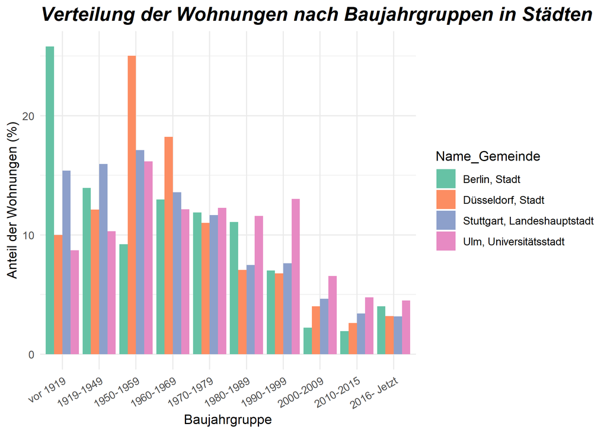

9. Wie in der vorherigen Aufgabe zu sehen war, unterscheidet sich die Situation in Städten in Bezug auf die jeweiligen Baujahre der Wohnungen deutlich. Es wäre noch spannend zu sehen, ob auch das Alter der Bewohner, die Familienstände, oder die Einwanderungshistorie der Bewohner mit unterschiedlichen Mietpreisen assoziiert sind. Hier sollen Sie in einem ersten generellen Schritt ein paar demografische Faktoren einbeziehen, inwiefern diese eine Auswirkung haben. Betrachten Sie folgende Eigenschaften genauer:
- Familienstand
- Alter der Bewohner
- Einwanderungsgeschichte

Erstellen Sie eine oder mehrere passende Diagramme oder Grafiken für die in Aufgabe 8 aufgeführten Städte.

Beschreiben und interpretieren Sie diese. Haben Sie diese Unterschiede erwartet? Begründen Sie warum oder warum nicht. Wo gibt es Ihrer Ansicht nach besondere Auffälligkeiten? Warum kann es bei der unterschiedlichen Einteilung der Altersgruppen zu Problemen kommen? Was wären Möglichkeiten, um etwaige Probleme zu vermeiden?

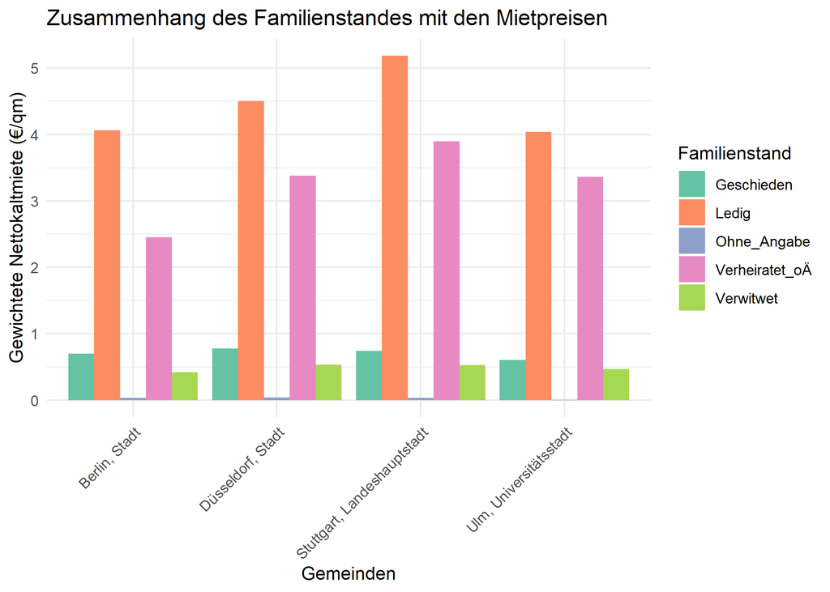

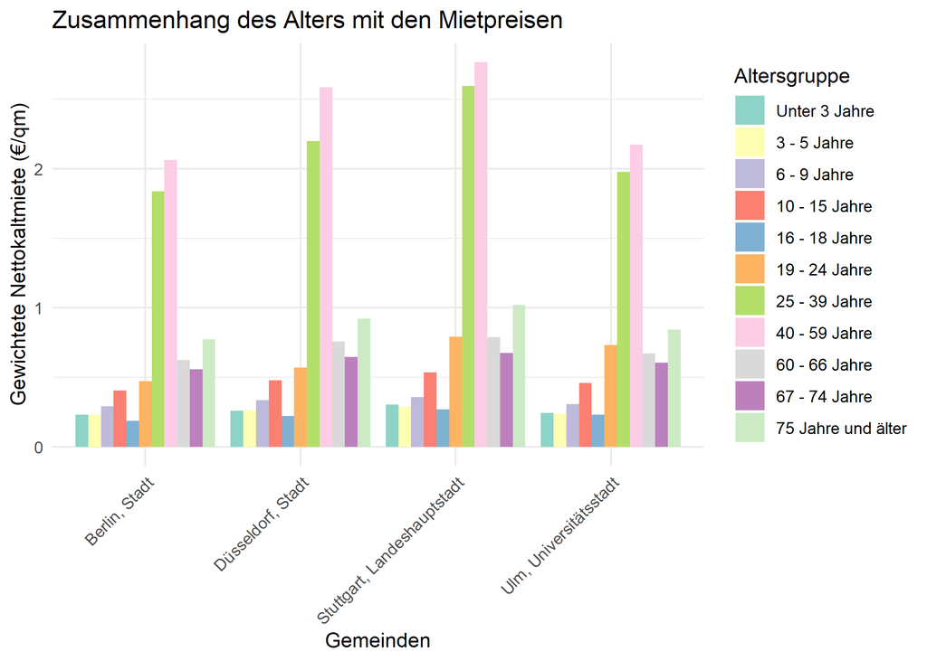

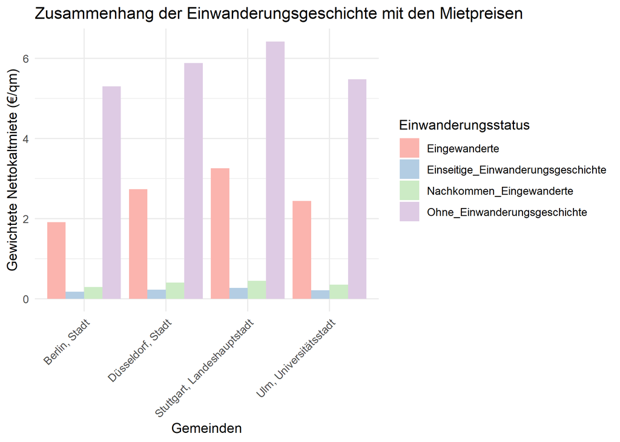

Die drei Grafiken zeigen verschiedene demografische Daten für vier deutsche Städte: Berlin, Düsseldorf, Stuttgart und Ulm. Jede Grafik beleuchtet einen anderen Aspekt der Bevölkerung: den Familienstand, die Altersverteilung und die Einwanderungsgeschichte.

Die Grafik zum Familienstand zeigt, dass Singles in allen Städten den höchsten Anteil an der Nettokaltmiete pro Quadratmeter tragen, besonders in Stuttgart mit über 5 Euro/m². Ehepaare und eingetragene Lebensgemeinschaften zahlen mit knapp 4 Euro/m² etwas weniger, während die Mieten für Verwitwete und Geschiedene in allen Städten unter einem Euro pro Quadratmeter liegen. Die geringe Mietbelastung für Geschiedene und Verwitwete lässt sich damit erklären, dass diese Gruppen in der Regel kleinere Wohnungen bewohnen, ähnlich wie Singles, die aufgrund der kleineren Wohnfläche höhere Quadratmeterpreise zahlen.

Die dritte Grafik bestätigt, dass in allen Städten Personen ohne Einwanderungsgeschichte den größten Anteil an der Miete tragen (ca. zwei Drittel), während Zuwanderer und deren Nachkommen einen kleineren Anteil haben. Dies hängt mit dem besseren Zugang zu Bildung und höherem Einkommen der Bevölkerung ohne Einwanderungsgeschichte zusammen, was ihnen ermöglicht, größere Wohnungen zu beziehen. Im Gegensatz dazu haben Zuwanderer und ihre Nachkommen oft schlechtere Chancen auf dem Arbeitsmarkt und sind bei der Wohnungswahl stärker eingeschränkt.

In den bisherigen Analysen wurden demografische und wohnungsbezogene Faktoren in verschiedenen Städten Deutschlands untersucht. Dabei lag der Fokus darauf, wie diese Merkmale in unterschiedlichen Regionen das Mietpreisniveau und dessen Struktur beeinflussen. Aufbauend auf diesen Erkenntnissen soll der Blick nun gezielt auf den Vergleich zwischen Ost- und Westdeutschland gelenkt werden. Diese regionale Differenzierung ermöglicht es, potenzielle Unterschiede und Gemeinsamkeiten zwischen den beiden Landesteilen genauer zu analysieren. Insbesondere wird betrachtet, wie sich die Mietpreisstruktur in Ost- und Westdeutschland darstellt und ob sich hierbei spezifische Muster oder Abweichungen erkennen lassen.

10. Betrachten Sie nun die Städte `Dresden, Stadt`, `Chemnitz, Stadt`, `Stuttgart, Landeshauptstadt`, `Ulm, Universitätsstadt`,`Düsseldorf, Stadt`und `Berlin, Stadt`. Vergleichen Sie in einem ersten Schritt die Anzahl an Einwohnern, den Anteil an Menschen, die deutscher Herkunft sind, den Anteil an neuen und alten Wohnungen, sowie die durchschnittlichen Mietpreise. Erweitern Sie ihre Analyse um die durschnittlichen Wohnflächen.

Erstellen Sie für die genannten Städte eine deskriptive Tabelle. Beschreiben und interpretieren Sie diese. Beantworten Sie insbesondere folgende Fragen:

- In wie weit könnte das Alter der Wohnungen eine Rolle für den Mietpreis spielen?
- Gibt es Auffälligkeiten zwischen den einzelnen Städten in Bezug auf Herkunft der Bewohner, Einwohner und Größe der Wohnungen?
- Warum könnte es problematisch sein, wenn Sie die Städte als ein Ganzes betrachten?
- Sind Ihre Ergebnisse auf die ganze Stadt verallgemeinerbar?
- Was sind ihrer Meinung nach Faktoren, die die unterschiedlichen Mietpreise in Ost und West erklären?
- Welche Maßnahmen wären geeignet, um in Düsseldorf, Ulm und Stuttgart die Mietpreisstruktur anzupassen und bezahlbaren Wohnraum zu schaffen?

Deskriptive Tabelle der Städte

| Stadt | Einwohner | Anteil_Deutsche | Durch.Miete (€/m²) | Durch.Wohnflaeche (m²) | Anteil_neue_Wohnungen | Anteil_alte_Wohnungen |
| --- | --- | --- | --- | --- | --- | --- |
| Berlin, Stadt | 3596999 | 0.69 | 7.67 | 73.22 | 0.06 | 0.49 |
| Chemnitz, Stadt | 240078 | 0.86 | 5.26 | 71.33 | 0.03 | 0.46 |
| Dresden, Stadt | 557782 | 0.86 | 6.92 | 71.24 | 0.07 | 0.44 |
| Düsseldorf, Stadt | 611258 | 0.64 | 9.24 | 77.56 | 0.06 | 0.47 |
| Stuttgart, Landeshauptstadt | 610458 | 0.62 | 10.39 | 79.76 | 0.07 | 0.48 |
| Ulm, Universitätsstadt | 127116 | 0.65 | 8.48 | 87.64 | 0.09 | 0.35 |

Die Tabelle führt die Städte Dresden, Berlin, Chemnitz, Stuttgart, Düsseldorf und Ulm auf. Zu sehen ist die Anzahl an Einwohnern, davon der Anteil an Deutschen, der durchschnittliche Mietpreis pro m², die durchschnittliche Wohnfläche in m², der Anteil an neuen und der Anteil an alten Wohnungen, in den jeweiligen Städten. So hat Berlin als Bundeshauptstadt die meisten Einwohner und Dresden mit Chemnitz haben den größten Anteil an deutschen Bürgern. Der Mietpreis ist in Stuttgart am höchsten und die durchschnittliche Wohnfläche in Ulm. Der Anteil an alten Wohnungen ist in Berlin am höchsten und der Anteil an neuen Wohnungen ist in Ulm am höchsten.

In wie weit könnte das Alter der Wohnungen eine Rolle für den Mietpreis spielen?

Gibt es Auffälligkeiten zwischen den einzelnen Städten in Bezug auf Herkunft der Bewohner, Einwohner und Größe der Wohnungen?

Man kann erkennen, dass in ostdeutschen Städten tendenziell der Anteil an deutschen Bewohnern höher ist. Sogar in Berlin, das als sehr multikulturell gilt ist der Anteil an deutschen Bewohnern höher als in allen westdeutschen Städten. Was außerdem auffällt ist, dass die durschschittliche Wohnfläche in den ostdeutschen Städten kleiner ist als in den westdeutschen Städten. Größere Städte wie Berlin und Düsseldorf haben tendenziell kleinere Wohnungen, da die Bebauung in dichter besiedelten Gebieten auf Effizienz abzielt. Berlin hat mit Abstand die höchste Einwohnerzahl, was auch mit einem breiten Spektrum an Miet- und Wohnmöglichkeiten einhergeht. Im Gegensatz dazu haben Städte wie Ulm oder Chemnitz deutlich geringere Einwohnerzahlen.

Warum könnte es problematisch sein, wenn Sie die Städte als ein Ganzes betrachten?

Jede Stadt hat demografische Unterschiede z.B. in der Bevölkerungsstruktur oder auch im Wohnungsbau. Würde man alle Städte als ein Ganzes betrachten, würden solche Unterschiede nicht zum Vorschein kommen.

Sind Ihre Ergebnisse auf die ganze Stadt verallgemeinerbar?

Nein. Städte haben oft wohlhabendere Gegenden, in denen z.B. der Mietpreis viel höher ist als in anderen Gegenden. Auch Vororte und Innenstädte unterscheiden sich sehr. Dadurch kann man die einzelnen Daten, wie z.B. der Mietpreis nicht als tatsächlicher Durchschnitt auf alle Wohnungen verteilt sehen, da in Innenstädten oder besseren Gegenden oftmals ein höhere Mietpreis herrscht.

Was sind ihrer Meinung nach Faktoren, die die unterschiedlichen Mietpreise in Ost und West erklären?

Ein Grund können wirtschaftliche Unterschiede sein. Ostdeutschland hat eine schwächere Wirtschaft als Westdeutschland, weshalb die Einkommen geringer sind und dadurch auch die Mieten nicht so hoch sein können. Ein anderer Grund könnte der demografische Wandel sein. Ostdeutsche Städte haben oft eine ältere Bevölkerung und eine geringere Nachfrage nach Wohnraum, was die Mietpreise dämpft. Außerdem könnten westdeutsche Städte attraktiver für Zuwanderer aufgrund der wirtschaftlichen Lage sein, weshalb es im Osten eine nicht so hohe Nachfrage nach Wohnungen gibt.

Welche Maßnahmen wären geeignet, um in Düsseldorf, Ulm und Stuttgart die Mietpreisstruktur anzupassen und bezahlbaren Wohnraum zu schaffen?

Förderung von sozialem Wohnungsbau kann Wohnraum bezahlbarer machen. Auch eine Subvention für die Modernisierung älterer Wohnungen könnten diese attraktiver machen. Eine weitere Maßnahme könnte eine Mietpreisbremse sein, wodurch in beliebten Stadtteilen die Mieten nicht endlos ansteigen.

11. Lesen Sie den [folgenden Artikel](https://www.tagesschau.de/wirtschaft/sozialwohnungen-bau-mangel-101.html). Dort werden Sozialwohnungen thematisiert, warum so viele fehlen und wer davon vor allem betroffen ist. Beantworten Sie anschließend folgende Fragen:
- Welche Bevölkerungsgruppen sind am stärksten von der Sozialwohnungsnot betroffen und inwiefern?
- Was sind Gründe, warum es zu wenige Sozialwohnungen gibt?
- Wie sieht die historische Entwicklung des Sozialwohnungsbaus aus, im Hinblick auf Vorhandensein von Wohnungen und Investitionen in den Bau von neuen Wohnungen?
- Welche Anreize könnten Investoren motivieren, mehr Sozialwohnungen zu bauen?
- Welche innovativen Ansätze können Bauherren verfolgen, um die Kosten für den Wohnungsbau zu senken?

Welche Bevölkerungsgruppen sind am stärksten von der Sozialwohnungsnot betroffen und inwiefern?

Besonders einkommensschwache Familien sind betroffen. Diese Gruppen haben auf dem Wohnungsmarkt kaum Chancen, bezahlbaren Wohnraum zu finden, selbst wenn sie einen Wohnberechtigungsschein besitzen. Die Nachfrage nach sozialem Wohnraum übersteigt das Angebot beträchtlich, was dazu führt, dass viele auf Wartelisten stehen.

Was sind Gründe, warum es zu wenige Sozialwohnungen gibt?

Während in den 1990er Jahren noch etwa drei Millionen Sozialwohnungen existierten, sind es heute nur noch rund 1,1 Millionen. Gründe für den Rückgang gibt es mehrere, zum einen fällt eine erhebliche Anzahl an Wohnungen nach 25 bis 30 Jahren aus der Mietbindung, was den Verlust an bezahlbarem Wohnraum verstärkt, da Neubauten diesen Rückgang nicht kompensieren können. Hinzu kommen die hohen Baukosten und die Zinserhöhungen, die den sozialen Wohnungsbau für Investoren zunehmend unattraktiv machen. Auch Lieferschwierigkeiten in den Lieferketten und allgemeine Probleme in der Baubranche beeinträchtigen die Planung und den Bau neuer Gebäude, was die Situation weiter verschärft.

Wie sieht die historische Entwicklung des Sozialwohnungsbaus aus, im Hinblick auf Vorhandensein von Wohnungen und Investitionen in den Bau von neuen Wohnungen?

Während die soziale Wohnraumversorgung in den 1990er Jahren umfangreicher war, ist die Anzahl der Sozialwohnungen seither drastisch gesunken. Die Förderung und Investitionen in den sozialen Wohnungsbau wurden über die Jahre nicht ausreichend an die steigende Nachfrage angepasst, und die Zahl der Neubauten konnte den Verlust aus der Entbindung älterer Sozialwohnungen nicht wettmachen.

Welche Anreize könnten Investoren motivieren, mehr Sozialwohnungen zu bauen?

Während an einigen Faktoren wie hohe Darlehenszinsen, hohe Preise und fehlende Fachkräfte am Bau derzeit nicht viel geändert werden kann, können auf andere Weise Anreize für Investoren geschaffen werden. Erhöhte Förderungen könnten Investoren dazu anregen, in den sozialen Wohnungsbau zu investieren. Zudem könnten weniger Auflagen und schnellere Genehmigungsprozesse den Bau von Sozialwohnungen vereinfachen und kostengünstiger gestalten. Weitere Anreize könnten durch Steuervergünstigungen für Firmen, wie sie im Modell der Wohngemeinnützigkeit geplant sind, geschaffen werden. All diese Maßnahmen würden die Attraktivität des sozialen Wohnungsbaus erhöhen und dazu beitragen, den Mangel an bezahlbarem Wohnraum zu verringern.

Welche innovativen Ansätze können Bauherren verfolgen, um die Kosten für den Wohnungsbau zu senken?

Eine Möglichkeit zur Reduzierung der Baukosten besteht darin, kleinere Treppenhäuser, geringere Wandstärken und den verstärkten Einsatz von Holzbau zu nutzen. Des Weiteren könnte durch den Verzicht auf Merkmale wie zum Beispiel Attikas bei Flachdächern Kosten gespart werden. Ein weiterer Ansatz wäre, sich mit bereits bestehenden hohen Standards im Schallschutz zufrieden zu geben, anstatt Steigerungen anzustreben. Außerdem werden die Bauherren dazu ermutigt, kreativer und innovativer zu werden, um den Wohnungsbau intelligenter und günstiger zu gestalten.

12. Gerade die Politik ist gefordert, bezahlbaren Wohnraum zu realisieren. Dabei gibt es eine Viezahl an politischen Maßnahmen, die aufgestellt wurden und umfangreich diskutiert werden. Betrachten Sie die folgenden Maßnahmen, welche helfen sollen, die angespannte Lage auf dem Mietmarkt zu entlasten. Argumentieren Sie, warum diese Maßnahmen sinnvoll/nicht sinnvoll sind und in welcher Art und Weise diese umgesetzt werden können.
1. “Fachleute fordern, die Regulierung von Bestandsmieten zu lockern, damit sich ihr Niveau den Neuvertragsmieten annähert, mehr Menschen umziehen und sich Wohnraum besser verteilt.”
2. “Eine weitere Möglichkeit wäre, Mieterhöhungen bei Neuvertragsmieten zu begrenzen.”
3. “Am einfachsten ist es, wenn vor allem in Großstädten, wo bezahlbarer Wohnraum fehlt, mehr gebaut wird.”
4. “Am besten wäre es, wenn zukünftig mehr Vermieter in regelmäßigen Abständen die Miete anpassen.”
1. Diese Maßnahme zielt darauf ab, dass sich Bestandsmieten den Neuvertragsmieten annähern. Das bedeutet, dass die Mieten vor allem in den Ballungsräumen steigen. Der Hintergrund dazu ist, dass die Mieter aus den Ballungsräumen wegziehen und in Gegenden ziehen, in denen die Miete geringer ist, um so den Wohnraum effizienter zu nutzen. Das könnte zwar tatächlich dafür sorgen, dass Mieter umziehen und sich so Wohnraum besser verteilt, allerdings hat nicht jeder die Möglichkeit spontan umzuziehen, da dies auch mit Kosten verbunden ist, was vor allem finanziell schwache Bürger trifft. So könnten finanziell Schwächere aus den Städten gedrängt werden. Außerdem werden so Leute gezwungen ihren alten Wohnort aufzugeben. Andere könnten sagen, dass sie den alten Wohnort behalten möchten und nicht umziehen wollen, wodurch sich dann aber die Miete für sie erhöht, was kontraproduktiv für einen bezahlbaren Wohnraum wäre. Daher ist diese Maßnahme weniger sinnvoll.
2. Ein Vorteil wäre, dass Mieten nicht in einer ständigen Mietpreisspirale weiter ansteigen, da sie bei Neuvertragsmieten beschränkt werden. Dadurch würde es Vermietern schwer gemacht werden vor allem in Ballungsräumen überhöhte Mieten zu verlangen. Ein Nachteil wäre, dass Investoren davon abgehalten werden können in den Wohnungsmarkt zu investieren, was langfristig wieder zu einer Verknappung des Wohnraums führen kann. Außerdem könnte es bürokratisch mit einem hohen Aufwand verbunden sein und zu rechtlichen Problemen führen. Es sollte zudem keine einheitliche Obergrenze eingeführt werden, sondern von der Region abhängig, da die Unterschiede zwischen den Regionen zu groß sind. Man kann also sagen, dass diese Maßnahme zunächst sinnvoll ist, die Umsetzung könnte aber schwierig sein.
3. Zunächst hört sich die Maßnahme sinnvoll an. Mehr Wohnraum entlastet den Markt und könnte die Mietpreise senken. Allerdings dauern solche Projekte oft sehr lange, weshalb eine schnelle Entlastung nicht zu erwarten ist. Das wohl größte Problem ist der Platzmangel, mit dem Großstädte zu kämpfen haben. Oft fehlt der Platz um neu zu bauen, ohne das die Lebensqualität zu stark eingeschrnänkt wird. Solche Bauprojekte sind auch immer mit hohen Kosten verbunden, was die Mietpreise kurzfristig steigen lassen könnte. Außerdem sollte darauf geachtet werden, was für eine Art von Neubau stattfindet. Vor allem in Großstädten, in denen es an Platz mangelt, könnte es für Investoren sinnvoller sein gehobenere Wohnungen zu bauen, um so mehr Miete zu bekommen. Dies würde allerdings zu keiner Marktentlastung führen. Diese Maßnahme kann also sinnvoll sein, wenn z.B. der soziale Wohnungsbau gefördert wird oder Anreize für Investoren bestehen auch für untere Einkommensgruppen zu bauen.
4. Vorteile einer solchen Maßnahme wären gewisse Planungssicherheiten, da sich so Mieter und Vermieter auf Mietänderungen einstellen können. Hinzukommt, dass große Sprünge der Miete verhindert werden, welche die Mieter zu sehr belasten könnten. Nachteile einer solchen Maßnahme sind, dass es ständige Mieterhöhungen gibt, welche den Markt weiter belasten könnten. Außerdem löst dieses Vorgehen nicht das Problem der Wohnungsnot, was in erster Linie für die hohen Mietpreise verantwortlich ist. Eine Umsetzung könnte in Verbindung mit einer Mietbegrenzung sinnvoll sein, da so verhindert wird, dass die Mieten zu stark steigen.

# Einzelne Stadtteile in Deutschland

In allen vorherigen Aufgaben haben Sie die Städte, Gemeinden oder auch Landkreise immer als ein Ganzes betrachtet. Jedoch ist es schwierig gerade in Großstädten wie Berlin, Düsseldorf oder auch Stuttgart allgemeine Aussagen über die Mietsituation auf Stadtebene zu treffen. Dies liegt unter anderem daran, dass unterschiedliche Stadtviertel unterschiedliche demografische Eigenschaften, sowie eine unterschiedliche Mietstruktur aufweisen können. Hier wäre es sinnvoll sich mit dem Stadtbild und der Verteilung der Mieten genauer auseinanderzusetzen, um zu sehen, wie sich Mieten innerhalb der Stadt verteilen. Wie in Aufgabe 10 zu sehen war, weisen die Städte im Westen Deutschlands untereinander, sowie die Städte im Osten ähnliche Merkmale auf, weshalb Sie sich in den folgenden Aufgaben auf je eine große und eine kleinere Stadt aus beiden Regionen konzentrieren.

13. In dieser Aufgabe sollen Sie ihren Datensatz aus Aufgabe 4, bei dem Sie Kartendaten und Informationen zu Mieten und LEQ auf 1km-Gitterebene heruntergeladen und zusammengefügt haben, verwenden und vier Karten zeichnen, welche die Verteilung der Nettokaltmieten in den Stadtteilen der Städte “Stuttgart, Landeshauptstadt”, “Ulm, Universitätsstadt”, “Chemnitz, Stadt” und “Dresden, Stadt” anschaulich visualisieren.

Erstellen Sie vier Grafiken, beschreiben und interpretieren diese. Gehen Sie insbesondere auf folgende Fragen ein:

- Welche Besonderheiten fallen Ihnen bei diesen Städten auf?
- Gibt es eine Segregation in Bezug auf die Mieten in einzelnen Stadtteilen?
- Falls es eine Segregation gibt, welche Konsequenzen könnte dies haben?
- Welche Rolle spielen geografische oder infrastrukturelle Faktoren bei den Mietpreisen?
- Gibt es Unterschiede zwischen Städten im Osten und Westen Deutschlands, falls ja, welche Einflüsse in Bezug auf Wirtschaft und Arbeitsmarkt könnte dies in den jeweiligen Städten haben?

*Hinweis:* Wenn Sie einheitliche Legenden für die Karten haben möchten und die vier Städte nebeneinander oder untereinander darstellen wollen, so empfiehlt sich das Paket `ggpubr` und dort der Befehl `ggarrange`.

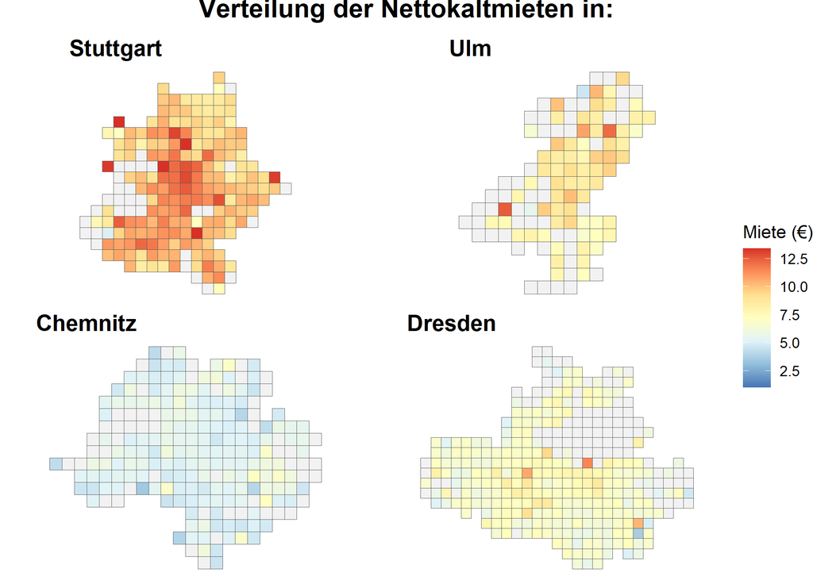

Die Grafik zeigt die Verteilung der durchschnittlichen Nettokaltmieten in Stuttgart, Ulm, Chemnitz und Dresden. Auffällig ist, dass Stuttgart eine starke Differenzierung zwischen teuren zentralen Stadtteilen und günstigeren Randgebieten aufweist. Ulm zeigt ähnliche, aber weniger ausgeprägte Muster. In Chemnitz sind die Mietpreise insgesamt niedrig und relativ gleichmäßig verteilt, während Dresden moderate Unterschiede aufweist, mit höheren Mieten in Elbnähe und zentrumsnahen Bereichen.

Eine Segregation ist vor allem in Stuttgart und Ulm erkennbar. Hohe Mietpreise in zentralen Gebieten verdrängen einkommensschwächere Haushalte an den Stadtrand. Dies kann soziale Ungleichheiten verstärken, den Zugang zu Bildung oder Arbeitsplätzen erschweren und längere Pendelwege verursachen. In den ostdeutschen Städten ist diese Trennung weniger stark ausgeprägt, jedoch in Dresden ansatzweise sichtbar.

Geografische und infrastrukturelle Faktoren spielen eine wichtige Rolle: In Stuttgart beeinflusst die hügelige Topografie die Mieten, während in Dresden die Elbnähe attraktiv ist. Gute Anbindungen und die Nähe zu Arbeitszentren und Universitäten treiben in allen Städten die Mietpreise in bestimmten Bereichen.

Zwischen Ost und West gibt es deutliche Unterschiede. Chemnitz und Dresden haben niedrigere Mietpreise als Stuttgart und Ulm, was auf die schwächere Wirtschaft und geringere Einkommen im Osten zurückzuführen ist. Insgesamt verdeutlicht die Grafik regionale Disparitäten, die soziale Spannungen fördern könnten und die Bedeutung wirtschaftlicher Förderung in ostdeutschen Städten unterstreichen.

14. Nachdem Sie in Aufgabe 13 die Verteilung der Mieten der einzelnen Stadtteile visualisiert haben, sollten Sie in dieser Aufgabe den Anteil der Leerstandsquoten in den Stadtteilen der Städte “Stuttgart, Landeshauptstadt”, “Ulm, Universitätsstadt”, “Chemnitz, Stadt” und “Dresden, Stadt” veranschaulichen.

Erstellen Sie vier Grafiken, beschreiben und interpretieren diese. Gehen Sie insbesondere auf folgende Fragen ein:

- Was könnten Gründe sein, dass die Leerstandsquote in bestimmten Stadtteilen höher ist, als in anderen?
- Welche Besonderheiten fallen Ihnen bei diesen Städten auf? Auch im Hinblick auf ihre Erkenntnisse aus Aufgabe 13.
- Vergleichen Sie die Grafiken aus Aufgabe 13 und Aufgabe 14. Was könnte der Grund für die unterschiedlichen Muster sein?
- Welche Maßnahmen ergreifen Städte mit hohen Leerstandsquoten, um diese zu reduzieren?

*Hinweis:* Wenn Sie einheitliche Legenden für die Karten haben möchten und die vier Städte nebeneinander oder untereinander darstellen möchten, so empfiehlt sich das Paket `ggpubr` und dort der Befehl `ggarrange`.

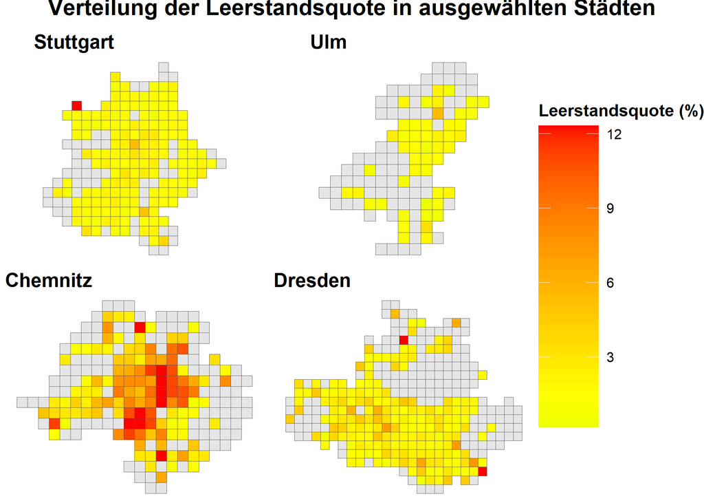

Im Vergleich zu den Mietpreiskarten aus Aufgabe 13 zeigt sich, dass Städte mit hohen Leerstandsquoten wie Chemnitz auch niedrigere Mietpreise haben. In diesen Gebieten gibt es mehr Leerstand, weil das Angebot größer ist als die Nachfrage. In Städten wie Stuttgart, die wirtschaftlich stabiler sind, sind sowohl die Mietpreise als auch die Nachfrage höher, was zu niedrigeren Leerstandsquoten führt.

Um hohe Leerstandsquoten zu reduzieren, ergreifen Städte Maßnahmen wie die Sanierung von Bestandsgebäuden, Neubauprojekte oder Umnutzung von Gewerbeimmobilien. Städte bieten oft auch Förderungen für Investoren an, die in Problemgebieten investieren. Diese Maßnahmen helfen, den Leerstand zu verringern und die Lebensqualität in betroffenen Stadtteilen zu verbessern.

15. Die aktuellen Mietpreise und deren Entwicklungen hindern in Deutschland immer mehr Menschen daran, dass sie sich eine neue geeignete Wohnung suchen. Personen, die aufgrund ihrer aktuellen Lebenssituation sich nach einer neuen Wohnung umsehen, finden oft keine oder können sich diese nicht leisten. Doch worin liegen die Ursachen und Probleme?

Beantworten Sie hierzu folgende Fragen:

- Was versteht man unter dem Lock-in-Effekt, speziell in Bezug auf den Mietmarkt? Wer ist davon vor allem betroffen und warum?
- Gibt es aktuell Möglichkeiten, die vor allem diese “betroffenen” Personen haben, um an bezahlbaren Wohnraum zu gelangen?
- Worin liegen die Ursachen, dass Bestandsmieten (Mieten aus bestehenden Verträgen) und Angebotsmieten (Mieten aus Neuverträgen) so stark voneinander abweichen?

Gehen Sie in ihrer Argumentation auch auf die Grafiken und Ergebnisse der Aufgaben 11, 13 und 14 ein.

Der Lock-in-Effekt beschreibt, dass Mieter trotz steigender Mietpreise oder veränderten Bedürfnissen in ihrer Wohnung bleiben, weil sie sich keine neue, bezahlbare Wohnung leisten können. Besonders betroffen sind Menschen mit niedrigem oder mittlerem Einkommen, da sie aufgrund der angespannten Marktlage in vielen Städten kaum eine bezahlbare Alternative finden. Dieser Effekt verstärkt sich besonders in Städten mit hohem Mietdruck.

Für diese Personen gibt es begrenzte Möglichkeiten, an bezahlbaren Wohnraum zu gelangen. Eine Option sind Sozialwohnungen, doch die Wartelisten sind oft lang und die Nachfrage übersteigt das Angebot. Eine weitere Möglichkeit wäre der Umzug in ländlichere Gebiete, aber hier stellen Faktoren wie Arbeitsplatznähe und Infrastruktur oft ein Hindernis dar.

Die starke Abweichung zwischen Bestandsmieten und Angebotsmieten ergibt sich aus der Mietpreisbremse, die Mieterhöhungen in bestehenden Verträgen begrenzt, während bei Neuverträgen höhere Mieten verlangt werden können, die sich an den aktuellen Marktbedingungen orientieren. Dieser Unterschied wird besonders in Städten mit hoher Nachfrage sichtbar und verschärft die Situation für Menschen, die eine neue Wohnung suchen.

# Stadt vs. Land

Bisher haben Sie sich intensiv mit der Wohnsituation in Deutschland auseinandergesetzt und dabei insbesondere die Unterschiede zwischen Ost- und Westdeutschland betrachtet. Im Fokus standen dabei die Mietpreisentwicklung und die Rolle verschiedener Faktoren wie demografische Merkmale, Leerstandsquote, Eigentümerquote, sowie die Wohnfläche. Diese Analysen haben wertvolle Erkenntnisse über die regionale Dynamik des Mietmarkts geliefert.

Nun sollen Sie ihren Blickwinkel erweitern und den Fokus auf eine weitere Ebene der Analyse richten. Im Kern sollen Sie den Unterschied zwischen städtischen Regionen, insbesondere Großstädten, und ländlichen Gebieten untersuchen. Hierbei soll die Mietstruktur in diesen beiden Raumtypen analysiert werden, ob sich die Strukturen von Stadt und Land voneinander unterscheiden.

16. Betrachten Sie in einem ersten Schritt die Wohnungen abhängig ihres Alters. Erstellen Sie dazu eine passende Grafik, die die Verteilung der Wohnungen nach Altersgruppen für die Stadt `Stuttgart, Landeshauptstadt` (Landkreis: Stuttgart, Stadtkreis) im Vergleich zum `Alb-Donau-Kreis` und `Ostalbkreis` darlegt.

Beschreiben und interpretieren Sie ihre Grafik. Woran könnte es liegen, dass es in Stuttgart (in der Stadt) deutlich mehr Altbauwohnungen als auf dem Land gibt? Könnten politische Maßnahmen ihrer Ansicht nach helfen, dass auch in Großstädten mehr neue Wohnungen erbaut und zur Vermietung zur Verfügung gestellt werden?

*Hinweis 1:* Nutzen Sie für die Visualisierung einen Mosaik- oder ein “stacked” Balkendiagramm. Eine Idee, wie Sie das Ganze darstellen können, finden Sie [hier](https://r-graph-gallery.com/).

*Hinweis 2:* Für Stuttgart soll der komplette Landkreis (“Stadtkreis”) untersucht werden.

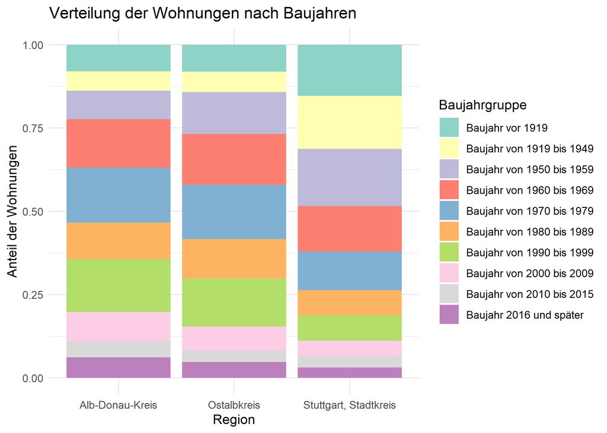

In der Grafik sehen wir ein “stacked” Balkendiagramm, das die Verteilung der Wohnungen nach Baujahren in drei verschiedenen Regionen zeigt: Stuttgart (Stadtkreis), Alb-Donau-Kreis und Ostalbkreis. Auf der x-Achse sind die Regionen aufgelistet, während die y-Achse den Anteil der Wohnungen in Prozent zeigt. Die verschiedenen Farben in den Balken repräsentieren die unterschiedlichen Baujahrgruppen. In der Stadt Stuttgart ist der Anteil der Altbauwohnungen im Vergleich zu ländlichen Gebieten wie dem Alb-Donau-Kreis und Ostalbkreis deutlich höher. Dies könnte darauf zurückzuführen sein, dass urbane Gebiete oft früher und stärker industrialisiert wurden, was zu einer früheren und umfangreicheren Bebauung des Stadtgebiets geführt hat. In ländlichen Gebieten hingegen gab es möglicherweise weniger Bedarf oder wirtschaftliche Anreize für eine Bebauung, weshalb der Anteil neuerer Wohnungen größer ist.

Politische Maßnahmen könnten durchaus einen entscheidenden Einfluss darauf haben, dass in urbanen Zentren mehr neue Wohnungen entstehen und zur Miete angeboten werden. Zum einen könnten Förderungen im Bereich des Wohnungsbaus ins Leben gerufen werden, die durch steuerliche Anreize ergänzt werden. Dadurch ließen sich Investoren motivieren, vermehrt in den Bau von Wohnraum zu investieren. Außerdem könnten bestehende Bauvorschriften überarbeitet und gelockert werden, um den Bauprozess zu vereinfachen und attraktiver zu gestalten. Zudem könnten Förderprogramme eingeführt werden, mit dem Ziel Bauland zu erschließen oder die Renovierung bereits bestehender Immobilien zu fördern, was den Bestand an Wohnraum erhöhen würde. Die staatliche Subventionierung von Bauprojekten könnte darüber hinaus Baukosten reduzieren, was Investitionen in zentralen Gebieten attraktiver machen würde.

In einem weiteren Schritt sollen Sie nun die Mietpreise und deren Verteilung analysieren. Hierbei sollen Sie neben der Leerstands- und Eigentümerquote auch auf die Verteilung der Wohnungen nach deren Wohnfläche achten und diese untersuchen.

17 (a). Erstellen Sie zuerst eine Tabelle, die die durchschnittlichen Mietpreise mit der Leerstands- und Eigentümerquote darstellt. Was fällt ihnen dabei besonders auf? Beschreiben und interpretieren Sie ihre Tabelle.

17 (b). Erstellen Sie eine weitere Grafik, die die Verteilung der Wohnungen nach den einzelnen Wohnungsgrößen(<40m² bis >=200m²) abbildet. Stellen Sie darüber hinaus den durchschnittlichen Mietpreis je Landkreis in einer weiteren Grafik dar. Beschreiben und interpretieren Sie ihre Grafiken. Gehen Sie insbesondere auf die Frage ein, ob es Sinn macht sich vor allem den Ostalbkreis oder Alb-Donau-Kreis als ein Ganzes anzusehen und inwieweit überhaupt ein Vergleich zwischen Stadt und ländlicher Region möglich ist.

*Hinweis:* Hier sollen Sie erneut auf dieselben Städte und Landkreise aus Aufgabe 16 eingehen!

| Region | Durchschnittliche Miete (€/m²) | Leerstandsquote (%) | Eigentümerquote (%) |
| --- | --- | --- | --- |
| Alb-Donau-Kreis | 6.37 | 5.34 | 71.44 |
| Ostalbkreis | 6.27 | 5.09 | 70.59 |
| Stuttgart, Stadtkreis | 10.39 | 3.46 | 31.15 |

1. In der Tabelle fällt auf, dass die durchschnittliche Miete in Stuttgart im Vergleich zu den ländlicheren Regionen wie dem Alb-Donau-Kreis und dem Ostalbkreis deutlich höher ist. Während die Mieten in den ländlicheren Landkreisen bei ca. 6,30 € pro Quadratmeter liegen, erreicht Stuttgart einen erheblich höheren Durchschnittspreis von 10,39 € pro Quadratmeter. Diese Diskrepanz spiegelt die hohe Nachfrage in städtischen Gebieten wider, wo Wohnraum knapper und begehrter ist. Vergleicht man die Leerstandsquoten, so hebt sich Stuttgart ebenfalls ab. Die Quote ist dort mit 3,46% relativ gering, was darauf hindeutet, dass die Nachfrage dort groß ist. In den ländlicheren Regionen liegen die Leerstandsquoten geringfügig höher, was auf eine geringere Nachfrage hinweist. Interessant ist auch die Betrachtung der Eigentümerquote. In den Regionen Alb-Donau-Kreis und Ostalbkreis sind die Eigentümerquoten mit ca. 70% relativ hoch, während sie in Stuttgart mit nur 31,15% deutlich niedriger ist. Dies könnte daran liegen, dass die Menschen in ländlichen Gebieten eher Eigentum bevorzugen, während in Stuttgart viele Menschen zur Miete wohnen, etwa wegen den hohen Immobilienpreisen oder aufgrund dessen, dass die Leute dort flexibler sind (berufliche oder persönliche Veränderungen erfordern Umzüge).

[figure not shown]

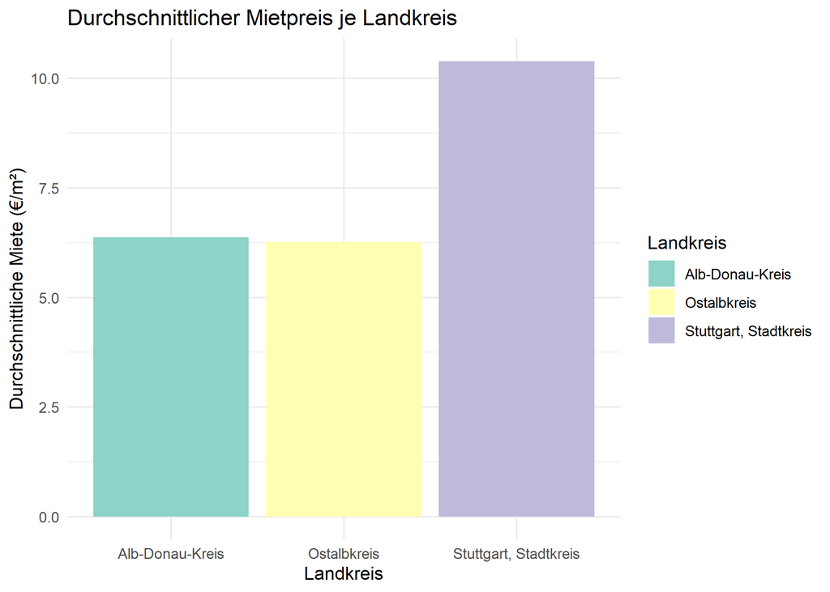

Das zweite Balkendiagramm zeigt die durchschnittlichen Mietpreise für die Landkreise Alb-Donau-Kreis, Ostalbkreis und Stuttgart, Stadtkreis. Das Diagramm gibt Auskunft darüber, wie hoch die Mieten in den unterschiedlichen Gebieten sind.Der Mietpreis ist in Stuttgart im Durchschnitt höher als in den ländlichen Landkreisen. Zu erklären ist das durch die hohe Nachfrage und den begrenzten Wohnraum in städtischen Gebieten. In den ländlichen Regionen, wie dem Alb-Donau-Kreis und dem Ostalbkreis, sind die Mietpreise niedriger, was auf ein größeres Angebot erklärt werden kann.

Die Betrachtung des Ostalbkreises oder des Alb-Donau-Kreises als Ganzes bietet einen guten Einblick in die Wohnsituation in diesen ländlichen Gebiete. Dennoch könnte es sein, dass es auch innerhalb der Landkreise Unterschiede zwischen den ländlicheren und städtischeren Regionen gibt. Solche Unterschiede könnten sich zum Beispiel in der Infrastruktur oder in der Nähe zu Universitäten und wirtschaftlichen Zentren zeigen.

Ein Vergleich zwischen Stadt und ländlicher Region ist möglich, allerdings ist es wichtig, dass man sich im klaren darüber ist, dass es Unterschiede zwischen den Regionen und deren Bewohnern gibt, die berücksichtigt werden müssen, damit keine falschen Schlüsse gezogen werden. In städtischen Regionen sind die Mietpreise höher und die Wohnungen kleiner (hohen Nachfrage und begrenzter Wohnraum), während ländliche Regionen größere und günstigere Wohnungen bieten. Städte sind dafür attraktiv durch viele Arbeitsplätze und Freizeitangebote, was jedoch höhere Lebenshaltungskosten mit sich bringt. Ländlichere Regionen bieten eine ruhigere Athmosphäre, jedoch mit weniger wirtschaftlichen Chancen. Öffentliche Verkehrsmittel sind in Städten besser, während auf dem Land das Auto wichtig ist. Die Lebensqualität hängt also von individuellen Bedürfnissen ab.

# Zusatzfrage (optional)

Diese Frage ist von der Bearbeitung her etwas schwieriger. Bevor Sie sich an diese Aufgabe machen, sollten Sie sicherstellen, dass Sie alle vorherigen Fragen ausführlich beantwortet haben. Eine korrekte Beantwortung dieser Frage gibt einen Punktebonus von 3 Punkten (das Projekt umfasst insgesamt 30 Punkte, inkl. Screencast).

Nachdem Sie sich in den bisherigen Aufgaben ausführlich mit den allgemeinen Einflussfaktoren auf die Mietpreise befasst haben, rückt nun ein spezifischer Aspekt in den Fokus: die Rolle der Heizungen. Insbesondere werden Sie untersuchen, wie unterschiedliche Heizungsarten und -systeme die Mietpreise beeinflussen können. Diese Betrachtung ermöglicht es ihnen, die bisherigen Analysen zu verfeinern und den Zusammenhang zwischen energetischen Standards und der Entwicklung von Mietkosten genauer zu erfassen. Aufgabe 18 führt Sie somit zu einem weiteren zentralen Detail der Mietpreisentwicklung, das insbesondere vor dem Hintergrund steigender Energiepreise und der Relevanz nachhaltiger Wohnformen an Bedeutung gewinnt.

18. Lesen Sie den Datensatz `Heiztypen_Zensus.csv` ein und speichern diesen als `heiztypen` ab. Neben den Ihnen bekannten Variablen, finden Sie dort 6 weitere Variablen, die Auskunft über die Heizarten der jeweiligen Wohnung geben. Diese werden wie folgt beschrieben:
- HEIZTYP__1: Gebäude mit Heizungsart Fernheizung (Fernwärme) (Anzahl)
- HEIZTYP__2: Gebäude mit Heizungsart Etagenheizung (Anzahl)
- HEIZTYP__3: Gebäude mit Heizungsart Blockheizung (Anzahl)
- HEIZTYP__4: Gebäude mit Heizungsart Zentralheizung (Anzahl)
- HEIZTYP__5: Gebäude mit Heizungsart Einzel- oder Mehrraumöfen (auch Nachtspeicherheizung) (Anzahl)
- HEIZTYP__6: Gebäude mit Heizungsart Keine Heizung im Gebäude oder in den Wohnungen (Anzahl)

Erstellen Sie eine neue Spalte `heiztypen_gesamt`, welche die Summe über alle Heiztypen hinweg bildet. Bestimmen Sie weiterhin den Anteil der jeweiligen Heiztypen je Gemeinde (als Anteil aller Heizarten). Nun sollen Sie eine oder mehrere passende Grafik(en) erzeugen, die je nach durchschnittlicher Größe der Wohnungen die Anteile der verschiedenen Heizungsarten abbilden. Erstellen Sie weiterhin eine oder mehrere passende Grafik(en) die den Zusammenhang zwischen den Heizungsarten und den durschnittlichen Mietpreisen darstellt. Wiederum soll der Anteil der verschiedenen Heizungsarten abhängig der Mietpreise abgebildet werden.

Beschreiben und interpretieren Sie ihre Schaubilder und gehen Sie insbesondere auf folgende Frage ein:

- Gibt es einen Zusammenhang zwischen der Heizungsart und der Größe der Wohnungen?
- Gibt es einen Zusammenhang zwischen der Heizungsart und den Mietpreisen?
- Was könnten Gründe sein, warum in bestimmten Wohnungsgrößen eher bestimmte Heizungstypen eingebaut werden und andere nicht?
- Warum könnte es sein, dass bei manchen Heizungsarten die Mietpreise höher sind als bei anderen?
- Was könnte die Bundesregierung machen, um trotz neuer und moderner Heizungssysteme die Mietpreise nach oben hin zu beschränken?

*Hinweis 1:* Überlegen Sie sich, ob es ihrer Ansicht nach Sinn macht, die jeweiligen Wohnungsgrößen und durchschnittlichen Mietpreise in Segmente zu unterteilen.

*Hinweis 2:* Eine Möglichkeit die Beziehung zwischen Heizungsarten und Wohnungsgrößen bzw. Heizungsarten und Mietpreisen zu visualisieren wäre beispielsweise ein “stacked” oder “grouped” Balkendiagramm. Überlegen Sie sich, warum diese Form der Darstellung besonders gut geeignet wäre.

19. Deshalb sollten Sie sich in einem ersten Schritt [diese Geogitter-Daten für die verschiedenen Heinzungsarten vom statistischen Bundesamt herunterladen](https://www.zensus2022.de/static/Zensus_Veroeffentlichung/Zensus2022_Heizungsart.zip). Speichern Sie die zip-Datei im Ordner `Daten` ab. Nutzen Sie erneut den Datensatz shape_file aus der Aufgabe 4 und joinen Sie die Informationen zu den Heizungsarten über die Variablen `x_mp_1km` und `y_mp_1km`.

In ihrem Datensatz können Sie sehen, dass es Einträge mit “-” gibt. Diese sollen sie für alle Heizungstypen durch 0 ersetzen. Achten Sie auch darauf, dass über alle Heizungstypen hinweg die Werte als numeric vorliegen.

Erstellen Sie nun für die Heizungsarten “Fernheizung”, “Etagenheizung” und “Zentralheizung” eine neue Spalte mit dem Anteil des jeweiligen Heizungstyps an allen Heizungen (`Insgesamt_Heizungsart`) je Gemeinde. Schließlich sollen Sie nun für die drei genannten Heizungsarten eine Karte erzeugen, welche den Anteil je Gitterebene im Stadtbezirk darstellt.

Beschreiben und interpretieren Sie ihre Grafiken. Berücksichtigen Sie dabei insbesondere folgende Fragen:

- Wo liegen Besonderheiten oder Muster in beiden Städten?
- Gibt es in Stuttgart und Dresden Stadtteile, bei denen bestimmte Heizungstypen in Einklang mit den Mietpreisen stehen, genauer gesagt, welche Heizungsarten korrelieren mit höheren oder niedrigeren Mietpreisen? Vergleichen Sie dazu die Ergebnisse aus Aufgabe 15.
- Was könnten Gründe sein, dass in bestimmten Stadtteilen vorwiegend eine bestimmte Form der Heizung eingebaut ist?
- Gibt es Unterschiede zwischen Ost- und Westdeutschland?
- Haben die Städte Stuttgart oder Dresden in den letzen Jahren Modernisierungen angestoßen oder Neuerungen umgesetzt und finanziell unterstützt, sodass es dort zu größeren Anpassungen bei der Heizungstechnik kam?

*Hinweis 1:* Sie sollen insgesamt für jede Stadt (Stuttgart und Dresden) drei verschiedene Karten erzeugen.

*Hinweis 2:* Achten Sie auf eine sinnvolle Einteilung und Darstellung in den Karten. Nutzen Sie die Karten aus vorherigen Aufgaben als Hilfestellung.

Abschließend sollen Sie die Zusatzaufgabe noch einmal rekapitulieren und einige Fragen dazu beantworten.

20. Sie sollen sich noch einmal bewusst werden, was Sie in den vorherigen Aufgaben analysiert haben und in welcher Form ihre Ergebnisse anwendbar und verallgemeinbar sind. Beantworten Sie dazu Frage 1 und 2.

Frage 1: Betrachten Sie hierzu noch einmal exemplarisch die Städte Stuttgart und Dresden.

- Sind die Zusammenhänge zwischen Mietpreisen in den Städten und sozioökonomischer Faktoren vor allem auf Unterschiede zwischen den Städten oder auf Unterschiede innerhalb der Stadt zurückzuführen. Bei welchen Faktoren ist dies der Fall, wo nicht?
- Wie kann der Staat im Hinblick auf die unterschiedlichen Heizungsarten in den Städten eingreifen, um Wohnraum preiswerter zu gestalten?

Frage 2: Schauen Sie sich noch einmal die Verteilung der Heizungsarten (Fern-, Etagen- und Zentralheizungen) für Stuttgart und Dresden in Aufgabe 19 an. Betrachten Sie im Vergleich dazu ihre Grafik aus Aufgabe 8, sowie ihre Tabelle in Aufgabe 13?

- Was fällt Ihnen hier auf?
- Gibt es bestimmte Heizungstypen, die nur in alten oder neuen Wohnungen vorkommen?
- Welche Schlüsse würden Sie ziehen, die mit Handlungen der Politik einhergehen?